# data_food_train

## serving_size_unit

| Feature | Result |
| --- | --- |
| Variable type | character |
| Number of missing obs. | 0 (0 %) |
| Number of unique values | 2 |
| Mode | “g” |

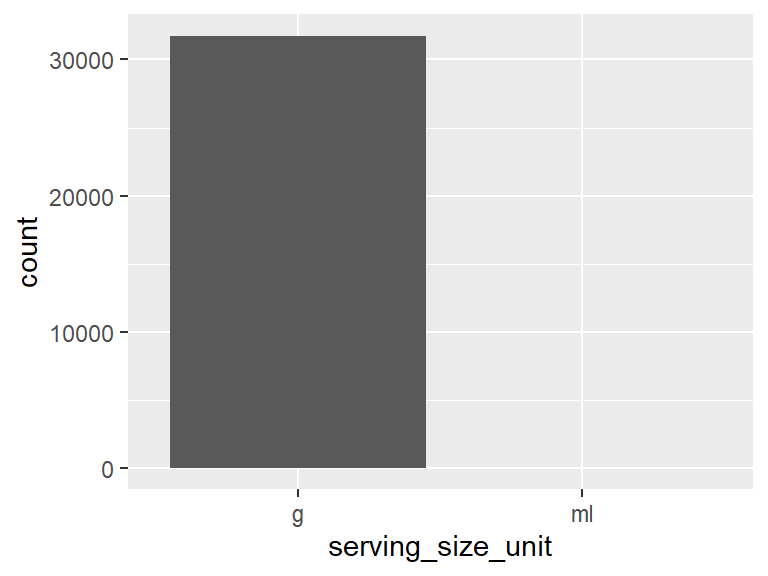

## household_serving_fulltext

| Feature | Result |
| --- | --- |
| Variable type | character |
| Number of missing obs. | 11 (0.03 %) |
| Number of unique values | 2206 |
| Mode | “1 onz” |

[figure not shown]

- The following suspected missing value codes enter as regular values: ".3 onz", ".35 onz", ".4 onz", ".42 onz", ".5 onz", …, ".75 onz", ".8 onz", ".84 onz", ".87 onz", ".88 onz" (3 values omitted).
- Note that the following levels have at most five observations: "-1.1 onz", ".3 onz", ".35 onz", ".4 onz", ".42 onz", …, "91 grm", "94 pretzels", "96 grm", "99 grm", "about 1/4 cup" (1754 values omitted).

## category

| Feature | Result |
| --- | --- |
| Variable type | character |
| Number of missing obs. | 0 (0 %) |
| Number of unique values | 6 |
| Mode | “popcorn_peanuts_seeds_related_snacks” |

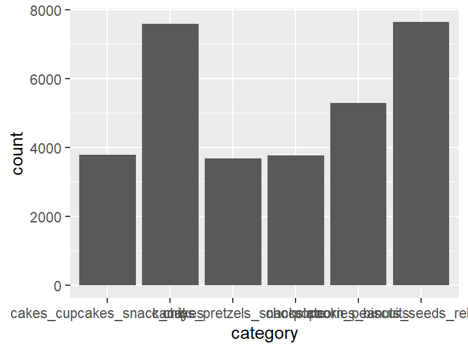

Report generation information:

- Created by: Yam rozen (username: `yamro`).
- Report creation time: Mon Jul 24 2023 15:16:42
- Report was run from directory: `C:/Users/yamro/OneDrive/desktop/limudim/ds_app/project-DSapps-yam-eyal`
- dataMaid v1.4.1 [Pkg: 2021-10-08 from CRAN (R 4.3.1)]
- R version 4.3.1 (2023-06-16 ucrt).
- Platform: x86_64-w64-mingw32/x64 (64-bit)(Asia/Jerusalem).
- Function call: `makeDataReport(data = data_food_train, output = "html", replace = TRUE)`